# Protein–Ligand Affinity Prediction

### Machine Learning-Based Prediction of Protein–Ligand Binding Affinity

## Project Overview

- Focuses on predicting protein–ligand binding affinity, an essential aspect of drug discovery.
- Protein features were extracted from amino acid composition and reduced using PCA for dimensionality reduction.
- Ligand features were derived from SMILES strings, converted into molecular fingerprints, and standardized.
- Combined protein and ligand features were used as input for a Random Forest Regressor.
- Model performance was evaluated using Mean Squared Error (MSE) and R² Score.

# Visualizations included:

- Scatter plot of Actual vs. Predicted Affinity.
- Residual distribution plot to analyze prediction errors.
- Residual histogram to examine error frequency.
- Demonstrates the integration of bioinformatics and machine learning for modeling molecular interactions.
- Provides a computational approach that can aid drug design and discovery by identifying potential binders.

# Step:1- Import All Libraries

In this step, I import all the essential Python libraries required for the project:

pandas (pd): Used for loading and handling tabular data such as the protein-ligand dataset.

numpy (np): Provides support for numerical operations, arrays, and mathematical computations.

rdkit (Chem, AllChem): A cheminformatics library used to process chemical structures from SMILES strings and generate molecular fingerprints.

sklearn.model_selection (train_test_split): Splits the dataset into training and testing sets for model evaluation.

sklearn.ensemble (RandomForestRegressor): Implements the Random Forest regression model for predicting binding affinity.

sklearn.metrics (mean_squared_error, r2_score): Provides performance metrics to evaluate the predictive accuracy of the model.

matplotlib.pyplot (plt): Used for data visualization, such as plotting actual vs. predicted values.

```python
import pandas as pd
import numpy as np
from rdkit import Chem
from rdkit.Chem import AllChem
from sklearn.model_selection import train_test_split
from sklearn.ensemble import RandomForestRegressor
from sklearn.metrics import mean_squared_error, r2_score
import matplotlib.pyplot as plt
```

# Step 2: Load Dataset

I loaded the protein_ligand.csv file into a pandas DataFrame using pd.read_csv(). print(data.head()) shows the first 5 rows to check that the dataset (Protein_Seq, Ligand_SMILES, Affinity) is loaded correctly.

```python
data = pd.read_csv('protein_ligand.csv')
print(data.head())
```

```
  Protein_Seq Ligand_SMILES  Affinity
0     MAVHLLT           CCO       5.6
1     GHKLITQ   C1=CC=CC=C1       7.2
2     ACDEFGH       CC(=O)O       6.3
3     KLMNPQR          NCCO       8.1
4     STVWYAC      C1CCCCC1       5.9
```

# Step 3: Protein Feature Extraction (Amino Acid Composition - AAC)

defined a list of 20 standard amino acids and create a function aa_composition() that calculates the relative frequency of each amino acid in a protein sequence. This converts each protein sequence into a 20-dimensional numerical feature vector, representing its amino acid composition.

```python
amino_acids = 'ACDEFGHIKLMNPQRSTVWY'

def aa_composition(seq):
    seq = seq.upper()
    length = len(seq)
    return [seq.count(aa)/length for aa in amino_acids]

protein_features = np.array(data['Protein_Seq'].apply(aa_composition).tolist())
```

```python
print(protein_features)
print(protein_features.shape)
```

[output not shown]

[output cut: 26 more lines]

[output not shown]

# This converts each protein sequence into a 20-dimensional numerical feature vector, representing its amino acid composition.

```python
import pandas as pd
import numpy as np

# amino acids list
amino_acids = 'ACDEFGHIKLMNPQRSTVWY'

# assuming protein_features is your (20,20) numpy array
aac_df = pd.DataFrame(protein_features, columns=list(amino_acids))

# optionally, add sequence IDs or indexes
aac_df.index = data.index  # or a column like data['Protein_ID']

# display the first few rows
print(aac_df.head())
```

```
          A         C         D         E         F         G         H  \
0  0.142857  0.000000  0.000000  0.000000  0.000000  0.000000  0.142857
1  0.000000  0.000000  0.000000  0.000000  0.000000  0.142857  0.142857
2  0.142857  0.142857  0.142857  0.142857  0.142857  0.142857  0.142857
3  0.000000  0.000000  0.000000  0.000000  0.000000  0.000000  0.000000
4  0.142857  0.142857  0.000000  0.000000  0.000000  0.000000  0.000000

          I         K         L         M         N         P         Q  \
0  0.000000  0.000000  0.285714  0.142857  0.000000  0.000000  0.000000
1  0.142857  0.142857  0.142857  0.000000  0.000000  0.000000  0.142857
2  0.000000  0.000000  0.000000  0.000000  0.000000  0.000000  0.000000
3  0.000000  0.142857  0.142857  0.142857  0.142857  0.142857  0.142857
4  0.000000  0.000000  0.000000  0.000000  0.000000  0.000000  0.000000

          R         S         T         V         W         Y
0  0.000000  0.000000  0.142857  0.142857  0.000000  0.000000
1  0.000000  0.000000  0.142857  0.000000  0.000000  0.000000
2  0.000000  0.000000  0.000000  0.000000  0.000000  0.000000
3  0.142857  0.000000  0.000000  0.000000  0.000000  0.000000
4  0.000000  0.142857  0.142857  0.142857  0.142857  0.142857
```

# Step 4: Amino Acid Composition Heatmap

This step visualizes the amino acid composition of proteins using a heatmap. Rows represent protein sequences, columns represent amino acids, and color intensity shows the relative frequency of each amino acid.

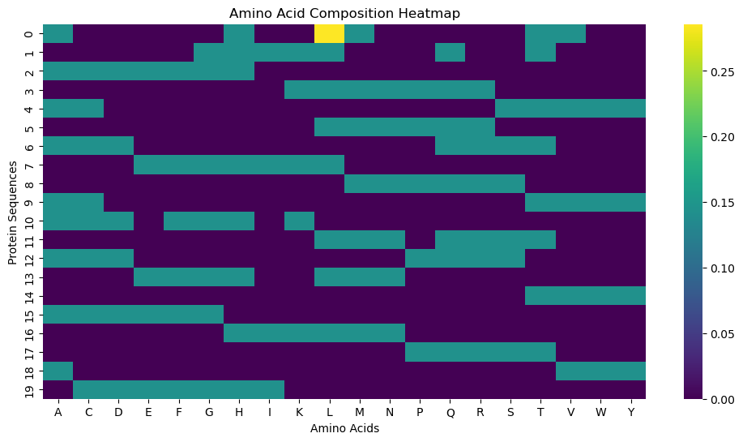

```python
import seaborn as sns
import matplotlib.pyplot as plt

plt.figure(figsize=(12,6))
sns.heatmap(aac_df, cmap='viridis')
plt.xlabel('Amino Acids')
plt.ylabel('Protein Sequences')
plt.title('Amino Acid Composition Heatmap')
plt.show()
```

# Step 5: Protein Feature Dimensionality Reduction (PCA)

This step applies Principal Component Analysis (PCA) to reduce the high-dimensional protein features into two principal components (PC1 & PC2). The scatter plot visualizes protein sequences in a 2D space, making it easier to observe clustering and patterns.

🔹 Why PCA?

Reduces noise and redundancy in data.

Helps in visualizing high-dimensional biological features.

Improves computational efficiency for machine learning models.

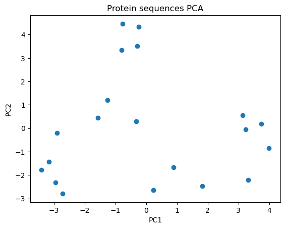

```python
from sklearn.decomposition import PCA

pca = PCA(n_components=2)
protein_pca = pca.fit_transform(protein_features_scaled)

import matplotlib.pyplot as plt
plt.scatter(protein_pca[:,0], protein_pca[:,1])
plt.xlabel('PC1')
plt.ylabel('PC2')
plt.title('Protein sequences PCA')
plt.show()
```

# Step 6: Standardization of Ligand Features

```python
from sklearn.preprocessing import StandardScaler

scaler_lig = StandardScaler()
ligand_scaled = scaler_lig.fit_transform(ligand_features)
```

```python
print("Mean:", ligand_scaled.mean())
print("Std Dev:", ligand_scaled.std())
```

```
Mean: -1.5612511283791264e-18
Std Dev: 0.2847010493482594
```

# Step 7: Feature Combination and Target Definition

The protein PCA features and scaled ligand features are combined into a single feature matrix X, while the binding affinity values from the dataset are defined as the target variable y.

```python
import numpy as np
from sklearn.model_selection import train_test_split
from sklearn.ensemble import RandomForestRegressor  # or Classifier if classification
from sklearn.metrics import mean_squared_error, r2_score, accuracy_score
```

```python
X = np.hstack([protein_pca, ligand_scaled])  # horizontally stack protein & ligand features
y = data['Affinity']
```

# Step 8: Combine Protein + Ligand Features

The shape and sample values of the combined feature matrix X and target variable y are printed. This ensures that the data has been correctly prepared before training the machine learning model.

```python
print("Shape of combined features X:", X.shape)
print("Shape of target y:", y.shape)
print("First row of X:", X[0])
print("First 5 values of y:", y[:5])
```

```
Shape of combined features X: (20, 1026)
Shape of target y: (20,)
First row of X: [-0.32785406  0.29318387  0.         ...  0.          0.
  0.        ]
First 5 values of y: 0    5.6
1    7.2
2    6.3
3    8.1
4    5.9
Name: Affinity, dtype: float64
```

# Step 9 : Model Training & prediction

The dataset is split into training and testing sets using an 80/20 ratio. A Random Forest Regressor is then trained on the training data (X_train, y_train). Once trained, the model predicts binding affinity values for the test set (X_test). The first few predictions are printed to verify the model’s output.

```python
# 1. Split dataset
X_train, X_test, y_train, y_test = train_test_split(
    X, y.values, test_size=0.2, random_state=42
)  # use y.values to make sure it's numeric numpy array

# 2. Train model
model = RandomForestRegressor(n_estimators=100, random_state=42)
model.fit(X_train, y_train)

# 3. Predict
y_pred = model.predict(X_test)
print("Predictions:", y_pred[:5])
```

```
Predictions: [6.532 7.033 6.42  6.441]
```

# Step 10: Evaluate

This step evaluates model performance using:

MSE: Average squared error between actual and predicted values.

R² Score: Explains how well the model fits the data.

Both metrics indicate prediction accuracy.

```python
mse = mean_squared_error(y_test, y_pred)
r2 = r2_score(y_test, y_pred)
print(f"Mean Squared Error: {mse:.2f}")
print(f"R^2 Score: {r2:.2f}")
```

```
Mean Squared Error: 0.43
R^2 Score: 0.03
```

# Step 11: Plot predictions

This scatter plot compares actual affinity values with model predictions, helping to visually assess prediction accuracy and identify deviations.

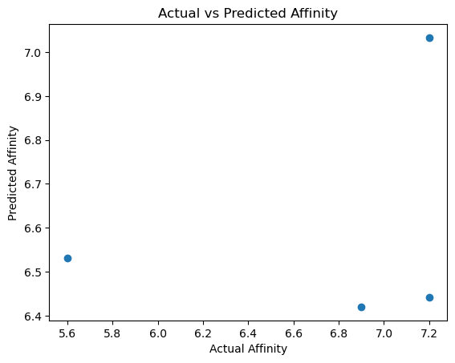

```python
import matplotlib.pyplot as plt
plt.scatter(y_test, y_pred)
plt.xlabel('Actual Affinity')
plt.ylabel('Predicted Affinity')
plt.title('Actual vs Predicted Affinity')
plt.show()
```

# Step 12 :Residual Analysis

This step plots the residuals (difference between actual and predicted values) against the predicted affinities. It helps evaluate model performance by showing whether errors are randomly distributed (ideal) or if patterns indicate bias in predictions.

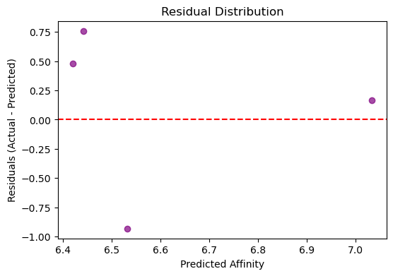

```python
residuals = y_test - y_pred

plt.figure(figsize=(6,4))
plt.scatter(y_pred, residuals, alpha=0.7, color="purple")
plt.axhline(0, color="red", linestyle="--")
plt.xlabel("Predicted Affinity")
plt.ylabel("Residuals (Actual - Predicted)")
plt.title("Residual Distribution")
plt.show()
```

# Step 13 : Histogram of residuals

This step plots a histogram of the residuals to visualize their distribution. A roughly normal (bell-shaped) distribution centered around zero indicates that the model errors are balanced, whereas skewed or wide distributions may suggest bias or high variance in predictions.

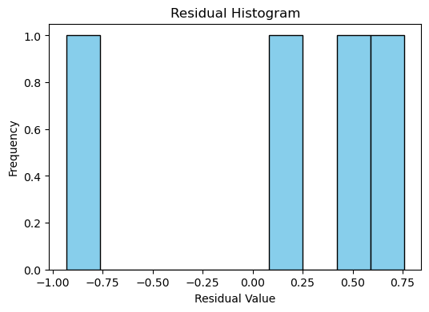

```python
plt.figure(figsize=(6,4))
plt.hist(residuals, bins=10, color="skyblue", edgecolor="black")
plt.xlabel("Residual Value")
plt.ylabel("Frequency")
plt.title("Residual Histogram")
plt.show()
```

# 📝 Conclusion

= We developed a machine learning model to predict protein–ligand binding affinity.

= Features were extracted from protein sequences (AAC + PCA) and ligand fingerprints.

= Future work includes larger datasets and advanced models (e.g., deep learning).

## Future improvements may include:

Expanding the dataset for better generalization. = Exploring advanced models like XGBoost, Support Vector Regression, or Deep Learning (CNN/RNN/Graph Neural Networks). Incorporating additional descriptors (structural, physicochemical, docking scores). = This project serves as a foundation for building more advanced computational drug discovery pipelines.